# Coursera Reporducible Research

## PA1 - Faraz S.

```r
setwd("~/R/Working Dir")
library(ggplot2)
library(scales)
library(Hmisc)
library(knitr)
opts_chunk$set(echo = TRUE)
```

First loading the data

```r
if(!file.exists('activity.csv')){
    unzip('activity.zip')}
activityData <- read.csv('activity.csv')
```

## What is mean total number of steps taken per day?

Storing the total steps by date

```r
stepsByDay <- tapply(activityData$steps, activityData$date, sum, na.rm=TRUE)
```

Histogram of the total number of steps taken each day

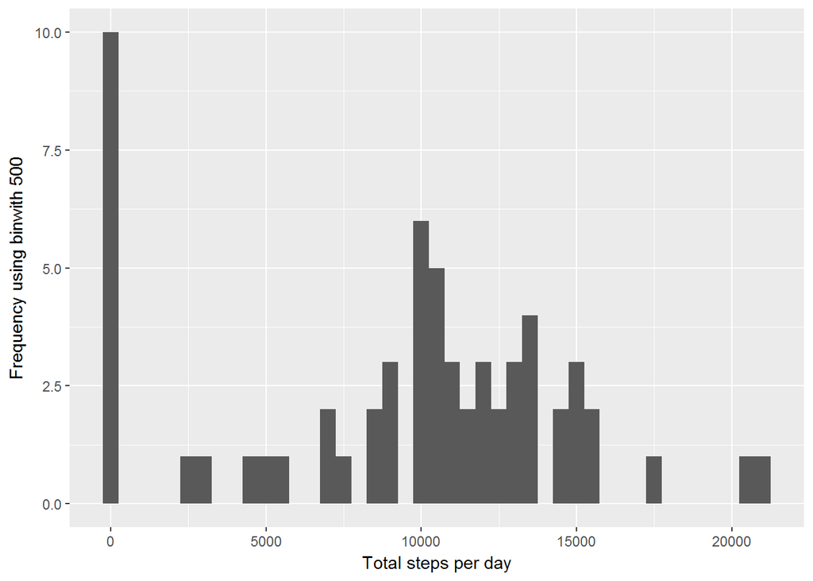

```r
qplot(stepsByDay, xlab='Total steps per day', ylab='Frequency using binwith 500', binwidth=500)
```

What is the mean and median total number of steps taken per day

```r
stepsByDayMean <- mean(stepsByDay)
stepsByDayMedian <- median(stepsByDay)
```

Mean: 9354.2295082 steps

Median: 10395 steps

## What is the average daily activity pattern?

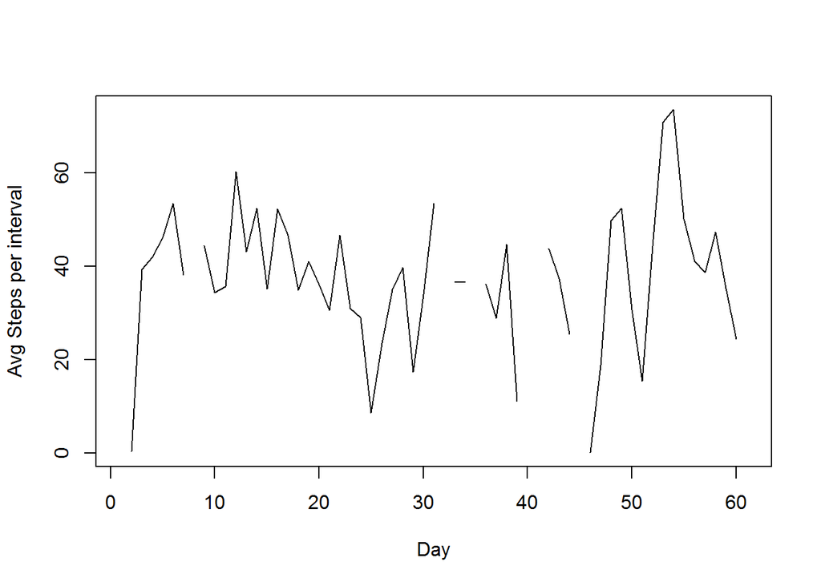

```r
daysum <- tapply(activityData$steps,activityData$date,sum)
averagesday <- tapply(activityData$steps,activityData$date,mean)
plot(averagesday,type="l", xlab="Day", ylab="Avg Steps per interval")
```

2. Which 5-minute interval, on average across all the days in the dataset, contains the maximum number of steps?

```r
intervalmax <- aggregate(steps ~ interval, activityData, mean)
stepsmax <- which.max(intervalmax$steps)
MostSteps <- intervalmax[stepsmax,]
```

Most Steps on average are found at interval ID:

835, 206.1698113 steps

## Inputing Missing Values

Calculate and report the total number of missing values in the dataset

```r
numMissingValues <- length(which(is.na(activityData$steps)))
```

Number of missing values is 2304

2. Devise a strategy for filling in all of the missing values in the dataset.
3. Create a new dataset that is equal to the original dataset but with the missing data filled in. Using 0 to replace the NA

```r
activityData2 <- activityData
activityData2$steps <- impute(activityData$steps, 0)
```

Make a histogram of the total number of steps taken each day, and recalculate the mean and median

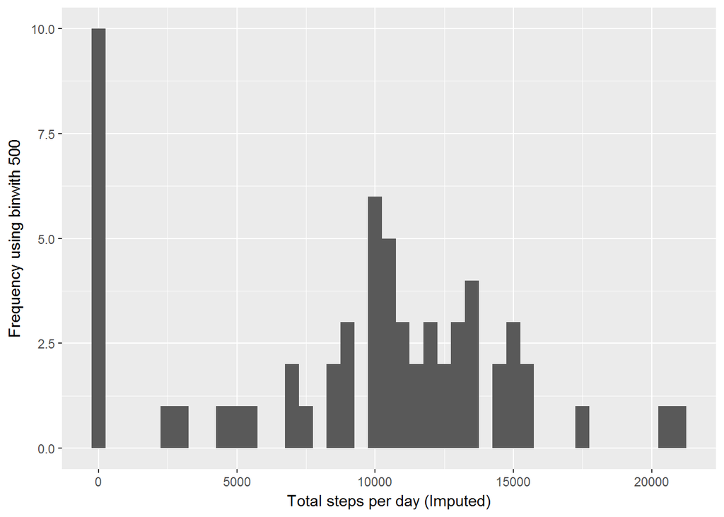

```r
stepsByDayImputed <- tapply(activityData2$steps, activityData2$date, sum)
qplot(stepsByDayImputed, xlab='Total steps per day (Imputed)', ylab='Frequency using binwith 500', binwidth=500)
```

The mean and median total number of steps taken per day

```r
stepsByDayMeanImputed <- mean(stepsByDayImputed)
stepsByDayMedianImputed <- median(stepsByDayImputed)
```

When replacing the NA with ‘0’ there are no differnces in the calculated mean and median.

## Activity Patterns between Weekdays and Weekends

```r
activityData2$dateType <-  ifelse(as.POSIXlt(activityData2$date)$wday %in% c(0,6), 'weekend', 'weekday')
```

Make a panel plot containing a time series plot

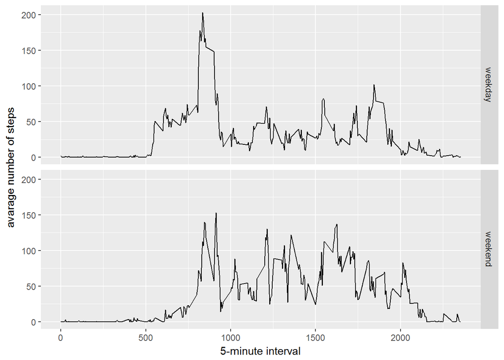

```r
averagedActivityDataImputed <- aggregate(steps ~ interval + dateType, data=activityData2, mean)
ggplot(averagedActivityDataImputed, aes(interval, steps)) +
    geom_line() +
    facet_grid(dateType ~ .) +
    xlab("5-minute interval") +
    ylab("avarage number of steps")
```